# youbike_data_analysis_NTU_ver3

```python
!gdown 1lr-s5EffXI29_fTP3OV7BAln2z1R6A0v
!file YouBike_traffic_2024.csv
```

```
Downloading...
From (original): https://drive.google.com/uc?id=1lr-s5EffXI29_fTP3OV7BAln2z1R6A0v
From (redirected): https://drive.google.com/uc?id=1lr-s5EffXI29_fTP3OV7BAln2z1R6A0v&confirm=t&uuid=3ed02e39-f5bd-4e58-a5a4-27b8a1e889ed
To: /content/YouBike_traffic_2024.csv
100% 713M/713M [00:08<00:00, 86.4MB/s]
YouBike_traffic_2024.csv: CSV Unicode text, UTF-8 (with BOM) text
```

```python
!gdown 1TJfyfcrxL3zq2oqxXqXFVITE5p2V8pAK
!file YouBike_traffic_2025.csv
```

```
Downloading...
From (original): https://drive.google.com/uc?id=1TJfyfcrxL3zq2oqxXqXFVITE5p2V8pAK
From (redirected): https://drive.google.com/uc?id=1TJfyfcrxL3zq2oqxXqXFVITE5p2V8pAK&confirm=t&uuid=921a4b45-2d90-48ea-94f8-6558c81fe6d3
To: /content/YouBike_traffic_2025.csv
100% 993M/993M [00:12<00:00, 79.0MB/s]
YouBike_traffic_2025.csv: CSV Unicode text, UTF-8 (with BOM) text
```

```python
import pandas as pd
import numpy as np
import matplotlib.pyplot as plt
```

```python
df_youbike_2024 = pd.read_csv('YouBike_traffic_2024.csv')
df_youbike_2024.info()
```

```
<class 'pandas.core.frame.DataFrame'>
RangeIndex: 6291342 entries, 0 to 6291341
Data columns (total 7 columns):
 #   Column          Dtype
---  ------          -----
 0   rent_time       object
 1   rent_station    object
 2   return_time     object
 3   return_station  object
 4   rent            object
 5   bike_type       object
 6   infodate        object
dtypes: object(7)
memory usage: 336.0+ MB
```

```python
df_youbike_2024
```

|  | rent_time | rent_station | return_time | return_station | rent | bike_type | infodate |
| --- | --- | --- | --- | --- | --- | --- | --- |
| 0 | 2024-01-22 08:00:00 | 新生和平路口東北側 | 2024-01-22 09:00:00 | 新生南路三段66號前 | 00:07:02 | NaN | 2024-01-22 |
| 1 | 2024-01-22 12:00:00 | 臺大小福樓東側 | 2024-01-22 12:00:00 | 捷運臺電大樓站(5號出口) | 00:12:21 | NaN | 2024-01-22 |
| 2 | 2024-01-22 21:00:00 | 捷運公館站(2號出口) | 2024-01-22 22:00:00 | 臺灣科技大學側門 | 00:19:06 | NaN | 2024-01-22 |
| 3 | 2024-01-22 23:00:00 | 捷運公館站(2號出口) | 2024-01-23 00:00:00 | 臺灣科技大學側門 | 00:26:58 | NaN | 2024-01-22 |
| 4 | 2024-01-22 18:00:00 | 臺大工綜館南側 | 2024-01-22 18:00:00 | 臺大椰林小舖 | 00:04:00 | NaN | 2024-01-22 |
| ... | ... | ... | ... | ... | ... | ... | ... |
| 6291337 | 2024-12-05 18:00:00 | 新生南路三段82號前 | 2024-12-05 18:00:00 | 臺大社會系館南側 | 00:06:02 | 一般車 | 2024-12-05 |
| 6291338 | 2024-12-05 20:00:00 | 辛亥復興路口西北側 | 2024-12-05 22:00:00 | 羅斯福路三段311號前 | 01:29:12 | 一般車 | 2024-12-05 |
| 6291339 | 2024-12-05 16:00:00 | 捷運公館站(2號出口) | 2024-12-05 17:00:00 | 捷運公館站(2號出口) | 00:56:22 | 一般車 | 2024-12-05 |
| 6291340 | 2024-12-05 19:00:00 | 捷運公館站(2號出口) | 2024-12-05 20:00:00 | 捷運台北101/世貿站(2號出口) | 00:39:28 | 一般車 | 2024-12-05 |
| 6291341 | 2024-12-05 21:00:00 | 捷運公館站(3號出口) | 2024-12-05 22:00:00 | 萬大路493巷 | 00:38:13 | 一般車 | 2024-12-05 |

6291342 rows × 7 columns

```python
file_url = 'https://tcgbusfs.blob.core.windows.net/dotapp/youbike/v2/youbike_immediate.json'
stationInfo = pd.read_json(file_url)
stationInfo.info()
```

```
<class 'pandas.core.frame.DataFrame'>
RangeIndex: 1824 entries, 0 to 1823
Data columns (total 18 columns):
 #   Column                  Non-Null Count  Dtype
---  ------                  --------------  -----
 0   sno                     1824 non-null   int64
 1   sna                     1824 non-null   object
 2   sarea                   1824 non-null   object
 3   mday                    1824 non-null   object
 4   ar                      1824 non-null   object
 5   sareaen                 1824 non-null   object
 6   snaen                   1824 non-null   object
 7   aren                    1824 non-null   object
 8   act                     1824 non-null   int64
 9   srcUpdateTime           1824 non-null   object
 10  updateTime              1824 non-null   object
 11  infoTime                1824 non-null   object
 12  infoDate                1824 non-null   object
 13  Quantity                1824 non-null   int64
 14  available_rent_bikes    1824 non-null   int64
 15  latitude                1824 non-null   float64
 16  longitude               1824 non-null   float64
 17  available_return_bikes  1824 non-null   int64
dtypes: float64(2), int64(5), object(11)
memory usage: 256.6+ KB
```

```python
stationInfo[stationInfo['sarea'] == '臺大公館校區']
```

|  | sno | sna | sarea | mday | ar | sareaen | snaen | aren | act | srcUpdateTime | updateTime | infoTime | infoDate | Quantity | available_rent_bikes | latitude | longitude | available_return_bikes |
| --- | --- | --- | --- | --- | --- | --- | --- | --- | --- | --- | --- | --- | --- | --- | --- | --- | --- | --- |
| 1759 | 500119005 | YouBike2.0_臺大水源舍區A棟 | 臺大公館校區 | 2026-11-06 20:02:02 | 汀洲路三段60巷2弄路側(A舍北側) | NTU Dist | YouBike2.0_NTU ShuiYuan Dorms(A) | Aly. 2， Ln. 60， Sec. 3， Tingzhou Rd. Dorms A(N... | 1 | 2026-11-06 20:02:52 | 2026-11-06 20:02:52 | 2026-11-06 20:02:02 | 2026-11-06 | 37 | 6 | 25.01493 | 121.53044 | 31 |
| 1760 | 500119006 | YouBike2.0_臺大卓越研究大樓 | 臺大公館校區 | 2026-11-06 20:02:02 | 臺大水源舍區C南側 | NTU Dist | YouBike2.0_NTU Complex for Research Excellence | NTU Prince House Chang Hsing Dorms C(South) | 1 | 2026-11-06 20:02:52 | 2026-11-06 20:02:52 | 2026-11-06 20:02:02 | 2026-11-06 | 92 | 2 | 25.01466 | 121.52917 | 89 |
| 1761 | 500119007 | YouBike2.0_臺大水源修齊會館 | 臺大公館校區 | 2026-11-06 20:02:02 | 思源街16號之1旁 | NTU Dist | YouBike2.0_NTU ShuiYuan HsiuChi House | No.16-1， Siyuan St. | 1 | 2026-11-06 20:02:52 | 2026-11-06 20:02:52 | 2026-11-06 20:02:02 | 2026-11-06 | 35 | 7 | 25.01411 | 121.52997 | 28 |
| 1762 | 500119008 | YouBike2.0_臺大檔案展示館 | 臺大公館校區 | 2026-11-06 20:02:02 | 臺大檔案展示館東北側 | NTU Dist | YouBike2.0_NTU Archives | NTU Archives(Northeast) | 1 | 2026-11-06 20:02:52 | 2026-11-06 20:02:52 | 2026-11-06 20:02:02 | 2026-11-06 | 10 | 7 | 25.01391 | 121.52895 | 3 |
| 1763 | 500119009 | YouBike2.0_臺大水源舍區B棟 | 臺大公館校區 | 2026-11-06 20:02:02 | 汀洲路三段60巷2弄路側(B舍北側) | NTU Dist | YouBike2.0_NTU ShuiYuan Dorms(B) | Aly. 2， Ln. 60， Sec. 3， Tingzhou Rd. Dorms B(N... | 1 | 2026-11-06 20:02:52 | 2026-11-06 20:02:52 | 2026-11-06 20:02:02 | 2026-11-06 | 30 | 11 | 25.01525 | 121.53009 | 19 |
| ... | ... | ... | ... | ... | ... | ... | ... | ... | ... | ... | ... | ... | ... | ... | ... | ... | ... | ... |
| 1819 | 500119099 | YouBike2.0_臺大博理館北側 | 臺大公館校區 | 2026-11-06 20:02:03 | 臺大博理館北側 | NTU Dist | YouBike2.0_NTU Barry Lam Hall(North) | NTU Barry Lam Hall(North) | 1 | 2026-11-06 20:02:52 | 2026-11-06 20:02:52 | 2026-11-06 20:02:03 | 2026-11-06 | 36 | 0 | 25.01945 | 121.54245 | 36 |
| 1820 | 500119100 | YouBike2.0_臺大博理館東側 | 臺大公館校區 | 2026-11-06 20:02:03 | 臺大博理館東側 | NTU Dist | YouBike2.0_NTU Barry Lam Hall(East) | NTU Barry Lam Hall(North) | 1 | 2026-11-06 20:02:52 | 2026-11-06 20:02:52 | 2026-11-06 20:02:03 | 2026-11-06 | 24 | 0 | 25.01929 | 121.54264 | 24 |
| 1821 | 500119101 | YouBike2.0_臺大德田館東北側 | 臺大公館校區 | 2026-11-06 20:02:03 | 臺大德田館東北側 | NTU Dist | YouBike2.0_NTU Der Tian Hall (Northeast) | NTU Der Tian Hall (Northeast) | 1 | 2026-11-06 20:02:52 | 2026-11-06 20:02:52 | 2026-11-06 20:02:03 | 2026-11-06 | 56 | 1 | 25.01976 | 121.54197 | 55 |
| 1822 | 500119102 | YouBike2.0_臺大普通教學館東側 | 臺大公館校區 | 2026-11-06 20:02:03 | 臺大普通教學館東側 | NTU Dist | YouBike2.0_NTU Putong Lecture Building (East) | NTU Putong Lecture Building (East) | 1 | 2026-11-06 20:02:52 | 2026-11-06 20:02:52 | 2026-11-06 20:02:03 | 2026-11-06 | 42 | 3 | 25.01861 | 121.53717 | 39 |
| 1823 | 500119103 | YouBike2.0_臺大次震宇宙館西側 | 臺大公館校區 | 2026-11-06 20:02:03 | 臺大次震宇宙館西側 | NTU Dist | YouBike2.0_NTU Cosmology Hall (West) | NTU Cosmology Hall (West) | 1 | 2026-11-06 20:02:52 | 2026-11-06 20:02:52 | 2026-11-06 20:02:03 | 2026-11-06 | 34 | 2 | 25.02162 | 121.53700 | 32 |

65 rows × 18 columns

# NTU Campus (臺大公館校區) YouBike Analysis

All trips that **start or end** at one of the stations returned by `stationInfo[stationInfo['sarea'] == '臺大公館校區']`.

Station names in the trip CSVs have no `YouBike2.0_` prefix, so the prefix is stripped from `sna` before matching.

```python
# Setup: map + Chinese font support (Colab)
!pip -q install staticmap
!apt-get -qq install -y fonts-noto-cjk > /dev/null

import os
import numpy as np
import pandas as pd
import matplotlib.pyplot as plt
from matplotlib import font_manager
import math
from staticmap import StaticMap
from PIL import Image, ImageDraw
import matplotlib.patheffects as pe
from matplotlib.lines import Line2D
from IPython.display import display, HTML

for f in ['/usr/share/fonts/opentype/noto/NotoSansCJK-Regular.ttc']:
    if os.path.exists(f):
        font_manager.fontManager.addfont(f)
        plt.rcParams['font.family'] = font_manager.FontProperties(fname=f).get_name()
plt.rcParams['axes.unicode_minus'] = False

# Colors
BLUE, ORANGE = '#2a78d6', '#eb6834'
GREEN, RED = '#0ca30c', '#d03b3b'
INK, INK2 = '#0b0b0b', '#52514e'
```

```python
# NTU stations from the live station API
ntu = stationInfo[stationInfo['sarea'] == '臺大公館校區'].copy()
ntu['name'] = ntu['sna'].str.replace('YouBike2.0_', '', regex=False).str.strip()
ntu['name_en'] = ntu['snaen'].str.replace('YouBike2.0_', '', regex=False).str.strip()
ntu = ntu.reset_index(drop=True)
ntu_names = set(ntu['name'])
print(f'{len(ntu)} NTU stations, total capacity {ntu["Quantity"].sum()} docks')
```

```
65 NTU stations, total capacity 2496 docks
```

```python
# Load trips that touch an NTU station (read in chunks to keep memory low)
def load_ntu_trips(path):
    cols = ['rent_time', 'rent_station', 'return_time', 'return_station', 'rent']
    parts = []
    for chunk in pd.read_csv(path, usecols=cols, dtype=str, chunksize=1_000_000):
        chunk['rent_station'] = chunk['rent_station'].str.strip()
        chunk['return_station'] = chunk['return_station'].str.strip()
        keep = chunk['rent_station'].isin(ntu_names) | chunk['return_station'].isin(ntu_names)
        parts.append(chunk[keep])
    return pd.concat(parts, ignore_index=True)

files = [f for f in ['YouBike_traffic_2024.csv', 'YouBike_traffic_2025.csv'] if os.path.exists(f)]
trips = pd.concat([load_ntu_trips(f) for f in files], ignore_index=True)

# Parse times and trip duration ('rent' column, e.g. '00:07:02')
trips['rent_time'] = pd.to_datetime(trips['rent_time'], errors='coerce')
trips['return_time'] = pd.to_datetime(trips['return_time'], errors='coerce')
trips['duration_s'] = pd.to_timedelta(trips['rent'], errors='coerce').dt.total_seconds()
trips = trips.dropna(subset=['rent_time', 'return_time', 'duration_s'])
# Basic sanity: drop non-positive durations and trips longer than a day
trips = trips[(trips['duration_s'] > 0) & (trips['duration_s'] <= 24 * 3600)]
trips = trips[trips['return_time'] >= trips['rent_time']].reset_index(drop=True)

trips['rent_hour'] = trips['rent_time'].dt.hour
trips['return_hour'] = trips['return_time'].dt.hour
trips['rent_at_ntu'] = trips['rent_station'].isin(ntu_names)
trips['return_at_ntu'] = trips['return_station'].isin(ntu_names)

n_days = trips['rent_time'].dt.normalize().nunique()   # days with data, used for daily averages
print(f'Files: {files}')
print(f'{len(trips):,} trips touching NTU stations over {n_days} days '
      f'({trips["rent_time"].min():%Y-%m-%d} to {trips["rent_time"].max():%Y-%m-%d})')

# Match check: NTU stations never seen in the trip data (e.g. renamed or newly opened)
seen = set(trips['rent_station']) | set(trips['return_station'])
missing = sorted(ntu_names - seen)
print(f'{len(ntu_names) - len(missing)}/{len(ntu_names)} NTU stations found in trip data')
if missing:
    print('Not found:', missing)
```

```
Files: ['YouBike_traffic_2024.csv', 'YouBike_traffic_2025.csv']
9,175,871 trips touching NTU stations over 729 days (2024-01-01 to 2025-12-31)
59/65 NTU stations found in trip data
Not found: ['臺大博理館北側', '臺大博理館東側', '臺大德田館東北側', '臺大數學研究中心(東側)', '臺大普通教學館東側', '臺大次震宇宙館西側']
```

## 1. Geographic Station Capacity Map

Maps are drawn with [StaticMap](https://github.com/komoot/staticmap): the OpenStreetMap tiles are downloaded once from Python, and the station circles are drawn on top. Circle area is proportional to the value shown.

```python
# --- Static basemap (downloaded once, reused by every map) ---
TILE_URL = 'https://tile.openstreetmap.org/{z}/{x}/{y}.png'
# If OSM tiles are still refused, switch to CARTO's light basemap:
# TILE_URL = 'https://a.basemaps.cartocdn.com/light_all/{z}/{x}/{y}.png'
HEADERS = {'User-Agent': 'NTU-YouBike-analysis/1.0 (student data-visualization notebook)'}
ZOOM, PAD, TILE = 16, 70, 256

def lon_to_x(lon, z=ZOOM):
    return (lon + 180.0) / 360.0 * 2 ** z

def lat_to_y(lat, z=ZOOM):
    r = math.radians(lat)
    return (1 - math.log(math.tan(r) + 1 / math.cos(r)) / math.pi) / 2 * 2 ** z

def y_to_lat(y, z=ZOOM):
    return math.degrees(math.atan(math.sinh(math.pi * (1 - 2 * y / 2 ** z))))

# Frame the map around the NTU stations
xs = ntu['longitude'].map(lon_to_x); ys = ntu['latitude'].map(lat_to_y)
X_C, Y_C = (xs.min() + xs.max()) / 2, (ys.min() + ys.max()) / 2
MAP_W = int((xs.max() - xs.min()) * TILE) + 2 * PAD
MAP_H = int((ys.max() - ys.min()) * TILE) + 2 * PAD
CENTER_LONLAT = [X_C / 2 ** ZOOM * 360.0 - 180.0, y_to_lat(Y_C)]

def to_px(lon, lat):
    return ((lon_to_x(lon) - X_C) * TILE + MAP_W / 2, (lat_to_y(lat) - Y_C) * TILE + MAP_H / 2)

try:
    sm = StaticMap(MAP_W, MAP_H, url_template=TILE_URL, headers=HEADERS)
except TypeError:          # older staticmap without the headers argument
    sm = StaticMap(MAP_W, MAP_H, url_template=TILE_URL)
BASEMAP = sm.render(zoom=ZOOM, center=CENTER_LONLAT).convert('RGBA')
print(f'Basemap {MAP_W}x{MAP_H}px at zoom {ZOOM}')

def radius(v, vmax, rmax=30, rmin=3):
    # Area-proportional radius in pixels
    return rmin + (rmax - rmin) * np.sqrt(abs(v) / vmax) if vmax > 0 else rmin

def hex_rgba(h, alpha):
    h = h.lstrip('#'); return tuple(int(h[i:i + 2], 16) for i in (0, 2, 4)) + (int(alpha * 255),)

def draw_circles(df, value_col, vmax, color_fn, alpha=0.65):
    """Draw one circle per station on a copy of the basemap. Biggest first so small ones stay visible."""
    img = BASEMAP.copy()
    layer = Image.new('RGBA', img.size, (0, 0, 0, 0))
    d = ImageDraw.Draw(layer)
    for _, r in df.reindex(df[value_col].abs().sort_values(ascending=False).index).iterrows():
        if r[value_col] == 0:
            continue
        x, y = to_px(r['longitude'], r['latitude']); rad = radius(r[value_col], vmax)
        d.ellipse([x - rad, y - rad, x + rad, y + rad], fill=hex_rgba(color_fn(r[value_col]), alpha),
                  outline=(255, 255, 255, 235), width=2)
    return Image.alpha_composite(img, layer)

def show_map(ax, img, df, value_col, title, n_labels=4, fmt='{:.0f}', vmax=None):
    ax.imshow(img); ax.set_axis_off()
    ax.set_title(title, loc='left', fontsize=12, color=INK, pad=8)
    # Direct labels on the largest few stations
    for _, r in df.reindex(df[value_col].abs().sort_values(ascending=False).index).head(n_labels).iterrows():
        x, y = to_px(r['longitude'], r['latitude'])
        rad = radius(r[value_col], vmax or df[value_col].abs().max())
        ax.annotate(f"{r['name']}  {fmt.format(abs(r[value_col]))}", (x + rad + 3, y), va='center',
                    fontsize=8, color=INK,
                    path_effects=[pe.withStroke(linewidth=3, foreground='white')])
    ax.text(MAP_W - 4, MAP_H - 4, '© OpenStreetMap contributors', ha='right', va='bottom',
            fontsize=6.5, color=INK2, backgroundcolor=(1, 1, 1, 0.7))
```

```
Basemap 903x564px at zoom 16
```

[figure not shown]

|  | name | name_en | Quantity |
| --- | --- | --- | --- |
| 0 | 臺大水源舍區C棟 | NTU Shui-Yuan Dorms C | 99 |
| 1 | 臺大博雅館西側 | NTU Liberal Education Classroom Building(West) | 99 |
| 2 | 臺大明達館北側(員工宿舍) | NTU Ming - Da Hall (Staff Dormitory) | 93 |
| 3 | 臺大卓越研究大樓 | NTU Complex for Research Excellence | 92 |
| 4 | 臺大總圖書館西南側 | NTU Main Library(Southwest) | 73 |
| ... | ... | ... | ... |
| 60 | 臺大檔案展示館 | NTU Archives | 10 |
| 61 | 臺大二號館 | NTU Building No.2 | 10 |
| 62 | 臺大農化新館西側 | NTU New Agricultural Chemistry Building(West) | 10 |
| 63 | 臺大小小福西南側 | NTU Xiao Xiao Fu Commissary(Southwest) | 10 |
| 64 | 臺大森林館北側 | NTU Forestry Building(North) | 10 |

65 rows × 3 columns

```python
qmax = ntu['Quantity'].max()
img = draw_circles(ntu, 'Quantity', qmax, lambda v: BLUE)
img.convert('RGB').save('map1_station_capacity.png')

fig, ax = plt.subplots(figsize=(12, 12 * MAP_H / MAP_W))
show_map(ax, img, ntu, 'Quantity', f'NTU YouBike station capacity — {len(ntu)} stations, '
         f'{ntu["Quantity"].sum():,} docks (labels: largest stations)', n_labels=6)
plt.tight_layout(); plt.show()
ntu[['name', 'name_en', 'Quantity']].sort_values('Quantity', ascending=False).reset_index(drop=True)
```

## 2. 所有腳踏車使用時間分布圖 — Bikes Borrowed and In Use by Hour

- **Borrowed**: average rentals per day that *start* at an NTU station in each hour.
- **In use**: average bikes on the road per day in each hour, for every trip that starts or ends at NTU. A trip counts in every hour from its rent hour to its return hour (the trip data is recorded at hourly resolution).

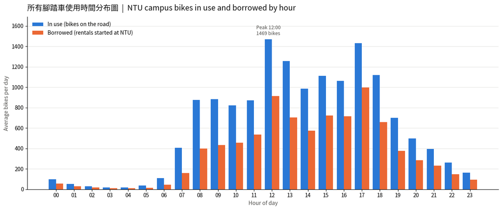

|  | hour | borrowed_per_day | in_use_per_day |
| --- | --- | --- | --- |
| 0 | 0 | 57.2 | 99.7 |
| 1 | 1 | 28.4 | 50.8 |
| 2 | 2 | 16.6 | 30.3 |
| 3 | 3 | 10.5 | 19.7 |
| 4 | 4 | 8.7 | 16.7 |
| 5 | 5 | 15.0 | 35.3 |
| 6 | 6 | 45.3 | 109.3 |
| 7 | 7 | 160.3 | 406.0 |
| 8 | 8 | 398.8 | 874.2 |
| 9 | 9 | 434.2 | 882.6 |
| 10 | 10 | 457.2 | 822.4 |
| 11 | 11 | 537.3 | 870.9 |
| 12 | 12 | 912.5 | 1468.8 |
| 13 | 13 | 703.8 | 1255.2 |
| 14 | 14 | 572.4 | 984.2 |
| 15 | 15 | 721.4 | 1110.0 |
| 16 | 16 | 714.2 | 1061.7 |
| 17 | 17 | 996.5 | 1430.7 |
| 18 | 18 | 659.5 | 1120.2 |
| 19 | 19 | 377.5 | 698.5 |
| 20 | 20 | 285.5 | 497.7 |
| 21 | 21 | 232.7 | 395.3 |
| 22 | 22 | 147.9 | 263.5 |
| 23 | 23 | 95.3 | 160.9 |

```python
# Borrowed per hour
borrowed = (np.bincount(trips.loc[trips['rent_at_ntu'], 'rent_hour'], minlength=24) / n_days)

# In use per hour: expand each trip over the hours it spans
start = trips['rent_time'].dt.floor('h')
span = ((trips['return_time'].dt.floor('h') - start) / pd.Timedelta(hours=1)).astype(int) + 1
span_v = span.to_numpy()
offsets = np.arange(span_v.sum()) - np.repeat(np.cumsum(span_v) - span_v, span_v)
hours_in_use = (np.repeat(start.dt.hour.to_numpy(), span_v) + offsets) % 24
in_use = np.bincount(hours_in_use, minlength=24) / n_days

hourly = pd.DataFrame({'hour': range(24), 'borrowed_per_day': borrowed.round(1),
                       'in_use_per_day': in_use.round(1)})

fig, ax = plt.subplots(figsize=(13, 5.5))
x = np.arange(24); w = 0.4
ax.bar(x - w/2, in_use, w, color=BLUE, label='In use (bikes on the road)')
ax.bar(x + w/2, borrowed, w, color=ORANGE, label='Borrowed (rentals started at NTU)')
ax.set_xticks(x, [f'{h:02d}' for h in x])
ax.set_xlabel('Hour of day', color=INK2)
ax.set_ylabel('Average bikes per day', color=INK2)
ax.set_title('所有腳踏車使用時間分布圖  |  NTU campus bikes in use and borrowed by hour',
             loc='left', fontsize=14, color=INK, pad=12)
ax.set_ylim(0, max(in_use.max(), borrowed.max()) * 1.15)
ax.spines[['top', 'right']].set_visible(False)
ax.grid(axis='y', color='#e5e5e2', linewidth=0.8); ax.set_axisbelow(True)
ax.legend(frameon=False, loc='upper left')
peak = int(np.argmax(in_use))
ax.annotate(f'Peak {peak:02d}:00\n{in_use[peak]:.0f} bikes', (peak - w/2, in_use[peak]),
            xytext=(0, 8), textcoords='offset points', ha='center', fontsize=9, color=INK2)
plt.tight_layout(); plt.savefig('chart2_hourly_usage.png', dpi=150); plt.show()
hourly
```

## 3. Average Commute Time Between Two Campus Stations

Trips where **both** the rent and return station are NTU stations, excluding round trips (same station). Outliers are removed **per station pair** with the IQR rule (keep Q1 − 1.5·IQR to Q3 + 1.5·IQR), which drops trips where the rider made stops along the way. Only pairs with at least `MIN_TRIPS` trips after cleaning are shown.

```python
MIN_TRIPS = 20

campus = trips[trips['rent_at_ntu'] & trips['return_at_ntu']
               & (trips['rent_station'] != trips['return_station'])].copy()

pair = campus.groupby(['rent_station', 'return_station'])['duration_s']
q1 = pair.transform(lambda s: s.quantile(0.25))
q3 = pair.transform(lambda s: s.quantile(0.75))
iqr = q3 - q1
clean = campus[(campus['duration_s'] >= q1 - 1.5 * iqr) & (campus['duration_s'] <= q3 + 1.5 * iqr)]
print(f'{len(campus):,} campus-to-campus trips; {len(campus) - len(clean):,} outliers removed '
      f'({(len(campus) - len(clean)) / max(len(campus), 1):.1%})')

def mmss(s):
    s = int(round(s)); return f'{s // 60}:{s % 60:02d}'

commute = (clean.groupby(['rent_station', 'return_station'])['duration_s']
           .agg(trips='size', avg_s='mean', median_s='median').reset_index())
commute = commute[commute['trips'] >= MIN_TRIPS].sort_values('trips', ascending=False)
commute['Avg commute time (min:sec)'] = commute['avg_s'].map(mmss)
commute['Median (min:sec)'] = commute['median_s'].map(mmss)

commute_table = commute.rename(columns={'rent_station': 'Rent station (租借站)',
                                        'return_station': 'Return station (歸還站)',
                                        'trips': 'Trips'})[
    ['Rent station (租借站)', 'Return station (歸還站)', 'Avg commute time (min:sec)',
     'Median (min:sec)', 'Trips']].reset_index(drop=True)
commute_table.to_csv('table3_campus_commute_times.csv', index=False, encoding='utf-8-sig')
print(f'{len(commute_table):,} station pairs with >= {MIN_TRIPS} trips (full table saved to CSV)')
print('Top 30 most-travelled pairs:')
display(commute_table.head(30).style.hide(axis='index'))
```

```
2,971,201 campus-to-campus trips; 365,466 outliers removed (12.3%)
3,353 station pairs with >= 20 trips (full table saved to CSV)
Top 30 most-travelled pairs:
```

| Rent station (租借站) | Return station (歸還站) | Avg commute time (min:sec) | Median (min:sec) | Trips |
| --- | --- | --- | --- | --- |
| 臺大新體育館東南側 | 臺大第一活動中心西南側 | 4:49 | 4:35 | 11055 |
| 臺大椰林小舖 | 臺大第一活動中心西南側 | 3:25 | 3:17 | 10813 |
| 臺大第一活動中心西南側 | 臺大椰林小舖 | 3:36 | 3:29 | 10782 |
| 臺大第一活動中心西南側 | 臺大新體育館東南側 | 4:18 | 4:08 | 9753 |
| 臺大小福樓東側 | 臺大第一活動中心西南側 | 2:27 | 2:15 | 9725 |
| 臺大第一活動中心西南側 | 臺大小福樓東側 | 2:13 | 1:59 | 9082 |
| 臺大社科院西側 | 臺大小福樓東側 | 3:24 | 3:14 | 8213 |
| 臺大小福樓東側 | 臺大大一女舍北側 | 3:44 | 3:37 | 8040 |
| 臺大小福樓東側 | 臺大社科院西側 | 3:26 | 3:17 | 7552 |
| 臺大大一女舍北側 | 臺大第一活動中心西南側 | 4:23 | 4:13 | 7439 |
| 臺大一號館 | 臺大第一活動中心西南側 | 3:11 | 3:03 | 7406 |
| 臺大第一活動中心西南側 | 臺大大一女舍北側 | 4:29 | 4:19 | 7402 |
| 臺大椰林小舖 | 臺大新體育館東南側 | 3:44 | 3:36 | 7189 |
| 臺大社科院西側 | 臺大第一活動中心西南側 | 3:07 | 2:51 | 7128 |
| 臺大新體育館東南側 | 臺大椰林小舖 | 4:09 | 3:58 | 6998 |
| 臺大女九舍西南側 | 臺大椰林小舖 | 4:29 | 4:20 | 6623 |
| 臺大第一活動中心西南側 | 臺大農業陳列館北側 | 3:54 | 3:39 | 6470 |
| 臺大大一女舍北側 | 臺大小福樓東側 | 3:42 | 3:32 | 6460 |
| 臺大新體育館東南側 | 臺大女九舍西南側 | 3:18 | 2:58 | 6207 |
| 臺大小福樓東側 | 臺大椰林小舖 | 3:02 | 2:52 | 6101 |
| 臺大樂學館東側 | 臺大新體育館東南側 | 2:01 | 1:57 | 6058 |
| 臺大女九舍西南側 | 臺大大一女舍北側 | 5:06 | 4:55 | 6039 |
| 臺大椰林小舖 | 臺大女九舍西南側 | 4:18 | 4:10 | 5999 |
| 臺大農業陳列館北側 | 臺大第一活動中心西南側 | 4:01 | 3:51 | 5845 |
| 臺大女九舍西南側 | 臺大新體育館東南側 | 2:55 | 2:42 | 5829 |
| 臺大新體育館東南側 | 臺大小福樓東側 | 3:22 | 3:02 | 5819 |
| 臺大第一活動中心西南側 | 臺大樂學館東側 | 2:53 | 2:41 | 5780 |
| 臺大樂學館東側 | 臺大第一活動中心西南側 | 3:02 | 2:48 | 5729 |
| 臺大椰林小舖 | 臺大小福樓東側 | 2:54 | 2:44 | 5507 |
| 臺大共同教室東南側 | 臺大第一活動中心西南側 | 2:35 | 2:23 | 5478 |

```python
# Look up any pair (both directions)
def commute_between(a, b):
    return commute_table[((commute_table['Rent station (租借站)'] == a) & (commute_table['Return station (歸還站)'] == b)) |
                         ((commute_table['Rent station (租借站)'] == b) & (commute_table['Return station (歸還站)'] == a))]

# Example: the busiest pair. Replace with any two station names, e.g. commute_between('臺大小福樓東側', '臺大總圖書館西南側')
top = commute_table.iloc[0]
commute_between(top['Rent station (租借站)'], top['Return station (歸還站)'])
```

|  | Rent station (租借站) | Return station (歸還站) | Avg commute time (min:sec) | Median (min:sec) | Trips |
| --- | --- | --- | --- | --- | --- |
| 0 | 臺大新體育館東南側 | 臺大第一活動中心西南側 | 4:49 | 4:35 | 11055 |
| 3 | 臺大第一活動中心西南側 | 臺大新體育館東南側 | 4:18 | 4:08 | 9753 |

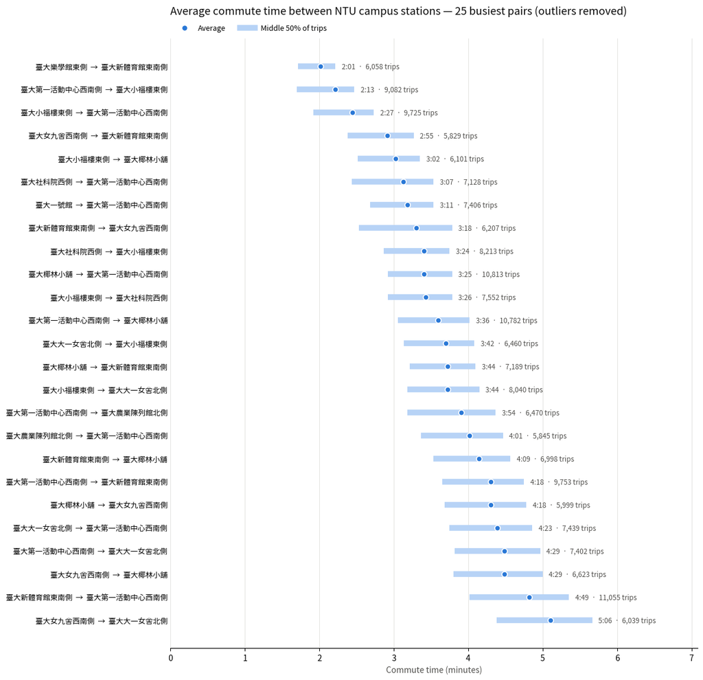

```python
# Chart: average commute time for the busiest campus station pairs
TOP_N = 25   # number of station pairs to show (the most-travelled ones)

pair_stats = (clean.groupby(['rent_station', 'return_station'])['duration_s']
              .agg(trips='size', avg='mean',
                   q1=lambda s: s.quantile(0.25), q3=lambda s: s.quantile(0.75))
              .reset_index())
pair_stats = (pair_stats[pair_stats['trips'] >= MIN_TRIPS]
              .nlargest(TOP_N, 'trips').sort_values('avg').reset_index(drop=True))
pair_stats[['avg', 'q1', 'q3']] = pair_stats[['avg', 'q1', 'q3']] / 60   # seconds -> minutes
pair_stats['label'] = pair_stats['rent_station'] + '  →  ' + pair_stats['return_station']

fig, ax = plt.subplots(figsize=(12, 0.4 * len(pair_stats) + 1.6))
y = np.arange(len(pair_stats))
ax.hlines(y, pair_stats['q1'], pair_stats['q3'], color='#b7d3f6', linewidth=7, zorder=2)
ax.scatter(pair_stats['avg'], y, s=45, color=BLUE, edgecolor='white', linewidth=1.2, zorder=3)
xmax = pair_stats['q3'].max()
for i, r in pair_stats.iterrows():
    ax.text(r['q3'] + xmax * 0.015, i, f"{mmss(r['avg'] * 60)}  ·  {r['trips']:,} trips",
            va='center', fontsize=8.5, color=INK2)

ax.set_yticks(y, pair_stats['label'], fontsize=9)
ax.invert_yaxis()                                   # fastest commute at the top
ax.set_xlim(0, xmax * 1.25)
ax.set_xlabel('Commute time (minutes)', color=INK2)
ax.set_title(f'Average commute time between NTU campus stations — {len(pair_stats)} busiest pairs '
             f'(outliers removed)', loc='left', fontsize=13, color=INK, pad=30)
ax.spines[['top', 'right', 'left']].set_visible(False)
ax.tick_params(axis='y', length=0)
ax.grid(axis='x', color='#e5e5e2', linewidth=0.8); ax.set_axisbelow(True)
ax.legend(handles=[Line2D([], [], marker='o', ls='', ms=7, mfc=BLUE, mec='white', label='Average'),
                   Line2D([], [], color='#b7d3f6', lw=7, label='Middle 50% of trips')],
          loc='lower left', bbox_to_anchor=(0, 1.0), ncol=2, frameon=False, fontsize=9)
plt.tight_layout(); plt.savefig('chart3_campus_commute_times.png', dpi=150, bbox_inches='tight'); plt.show()
```

## 4 & 5. Station Activity and Net Flow at 09:00, 12:00 and 16:00

For each NTU station and hour, averaged over all days in the data:

- **Total activity** = rentals + returns
- **Net flow** = returns − rentals
  - 🟢 **Demand (green)**: more returns than rentals — riders are arriving, so the station needs empty docks.
  - 🔴 **Supply (red)**: more rentals than returns — riders are leaving, so the station supplies bikes.

Circle sizes use one scale across the three hours, so they can be compared directly.

```python
HOURS = [9, 12, 16]

rent_h = (trips[trips['rent_at_ntu']].groupby(['rent_station', 'rent_hour']).size()
          .rename_axis(['name', 'hour']))
ret_h = (trips[trips['return_at_ntu']].groupby(['return_station', 'return_hour']).size()
         .rename_axis(['name', 'hour']))
flow = pd.concat({'rentals': rent_h, 'returns': ret_h}, axis=1).fillna(0) / n_days
flow['activity'] = flow['rentals'] + flow['returns']
flow['net'] = flow['returns'] - flow['rentals']

# Every NTU station x every hour (stations with no trips get 0)
idx = pd.MultiIndex.from_product([sorted(ntu_names), range(24)], names=['name', 'hour'])
flow = (flow.reindex(idx, fill_value=0).reset_index()
        .merge(ntu[['name', 'name_en', 'latitude', 'longitude', 'Quantity']], on='name'))
flow_sel = flow[flow['hour'].isin(HOURS)]

def three_panel(images, value_col, titles, suptitle, legend, fname, fmt):
    fig, axes = plt.subplots(1, 3, figsize=(21, 7 * MAP_H / MAP_W + 1.2))
    for ax, h, img, t in zip(axes, HOURS, images, titles):
        show_map(ax, img, flow_sel[flow_sel['hour'] == h], value_col, t, n_labels=3, fmt=fmt,
                 vmax=flow_sel[value_col].abs().max())
    fig.suptitle(suptitle, x=0.01, ha='left', fontsize=15, color=INK)
    fig.legend(handles=legend, loc='upper right', frameon=False, fontsize=10, ncol=len(legend))
    plt.tight_layout(); plt.savefig(fname, dpi=150, bbox_inches='tight'); plt.show()
```

[figure not shown]

| hour name | 9 | 12 | 16 |
| --- | --- | --- | --- |
| 臺大女九舍西南側 | 63.2 | 72.3 | 39.0 |
| 臺大新體育館東南側 | 50.0 | 74.5 | 63.1 |
| 臺大第一活動中心西南側 | 48.7 | 140.4 | 100.8 |
| 臺大小福樓東側 | 38.6 | 122.8 | 64.6 |
| 臺大樂學館東側 | 38.4 | 45.3 | 30.0 |
| 臺大社會系館南側 | 37.8 | 42.5 | 29.2 |
| 臺大社科院西側 | 33.3 | 80.9 | 50.6 |
| 臺大鹿鳴堂東側 | 31.5 | 42.9 | 25.0 |
| 臺大黑森林西側 | 30.1 | 40.7 | 25.2 |
| 臺大共同教室東南側 | 28.3 | 39.2 | 20.8 |

```python
# 4. Activity map
amax = flow_sel['activity'].max()
activity_imgs = []
for h in HOURS:
    img = draw_circles(flow_sel[flow_sel['hour'] == h], 'activity', amax, lambda v: BLUE)
    img.convert('RGB').save(f'map4_activity_hour{h:02d}.png')
    activity_imgs.append(img)

three_panel(activity_imgs, 'activity', [f'Hour {h:02d}:00' for h in HOURS],
            'Average total activity per station (rentals + returns per day)',
            [Line2D([], [], marker='o', ls='', ms=10, mfc=BLUE, mec='white', alpha=.7,
                    label='Rentals + returns per day (same scale in all panels)')],
            'map4_activity_9_12_16.png', '{:.1f}')
(flow_sel.pivot_table(index='name', columns='hour', values='activity').round(1)
 .sort_values(HOURS[0], ascending=False).head(10))
```

[figure not shown]

| hour name | 9 | 12 | 16 |
| --- | --- | --- | --- |
| 臺大女九舍西南側 | 44.5 | -8.5 | -16.1 |
| 臺大社會系館南側 | 31.5 | -3.3 | -10.4 |
| 臺大第一活動中心西南側 | 28.4 | 0.0 | -19.0 |
| 臺大圖資系館北側 | 20.7 | -3.8 | -10.6 |
| 臺大工綜館南側 | 13.8 | 1.3 | -9.8 |
| ... | ... | ... | ... |
| 臺大水源舍區A棟 | -4.8 | -2.0 | 1.3 |
| 臺大一號館 | -5.7 | 1.1 | 1.7 |
| 臺大水源舍區B棟 | -6.0 | -1.8 | 2.1 |
| 臺大人文館 | -6.1 | -0.2 | -0.2 |
| 臺大卓越研究大樓 | -9.5 | -3.7 | -0.6 |

65 rows × 3 columns

```python
# 5. Net flow map
nmax = flow_sel['net'].abs().max()
net_imgs = []
for h in HOURS:
    img = draw_circles(flow_sel[flow_sel['hour'] == h], 'net', nmax,
                       lambda v: GREEN if v > 0 else RED, alpha=0.7)
    img.convert('RGB').save(f'map5_netflow_hour{h:02d}.png')
    net_imgs.append(img)

three_panel(net_imgs, 'net', [f'Hour {h:02d}:00' for h in HOURS],
            'Average net flow per station (returns − rentals per day)',
            [Line2D([], [], marker='o', ls='', ms=10, mfc=GREEN, mec='white', label='Demand: more returns than rentals'),
             Line2D([], [], marker='o', ls='', ms=10, mfc=RED, mec='white', label='Supply: more rentals than returns')],
            'map5_netflow_9_12_16.png', '{:.1f}')
(flow_sel.pivot_table(index='name', columns='hour', values='net').round(1)
 .sort_values(HOURS[0], ascending=False))
```